# Lab 1

January 28, 2019

## Link to repository on github:

https://github.com/stharms/Stat585Lab1Group10

## Book

1.) The last word in chapter 15 is “packages”, unless you include the footnotes, in which case the last word is “pseudo-class”

2.) The biggest problem I encountered was the number of R packages that we needed to install or update. I counted at least 7 that I needed to install, as well as many others that needed to be updated. Additionally, my R version was out of date and this affected the functionality of several packages as well. One package was not even available on CRAN and had to be installed with devtools. The solution is to be persistent and continue updating until it works. We also need to be careful about namespaces because some of the same command names are used in different packages.

3.) [When things don’t work…] Example question: I am trying to install the package ‘emo’ for R in order to access emojis. It is not available in CRAN. How do I install a package directly in Rstudio if install.packages(“emo”) does not work?

One solution: following instructions from the emo package github page, I used devtools::install_github(“hadley/emo”) to install the package. This required me to install devtools package, but it still did not work. There are several dependencies that also needed to be updated and/or reinstalled. I have attempted to reinstall the “stringi” package twice and reinstalled the developer tools to get this to work, restarting Rstudio each time.

## About Weather Data

```r
library(tidyverse)
library(ggmap)
```

[output not shown]

[output not shown]

[output cut: 31 more lines]

[output not shown]

[output not shown]

[output cut: 55 more lines]

[output not shown]

[output not shown]

[output not shown]

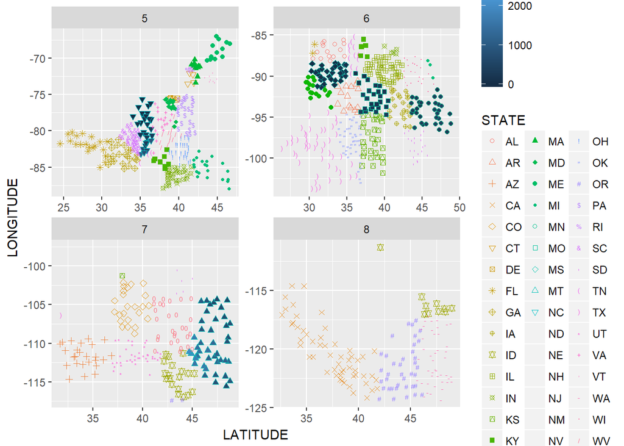

```r
library(maps)
library(mapdata)
stations <- read_fwf(file = "./ushcn-v2.5-stations.txt", fwf_widths(c(2, 1, 2, 6, 10, 10, 6, 4, 30, 7, 7, 7, 5), c("COUNTRY","NETWORK","ID_placeholder","COOP_ID", "LATITUDE", "LONGITUDE", "ELEVATION", "STATE", "NAME", "COMPONENT_1", "COMPONENT_2", "COMPONENT_3", "UTC_OFFSET")))
ggplot(data=stations, aes(x=LATITUDE,y=LONGITUDE,fill=ELEVATION ,group=STATE)) +
geom_point(aes(shape=STATE, color=STATE)) +scale_shape_manual(values=c(1:48)) +
facet_wrap(~UTC_OFFSET,scale ="free" )
```

```r
# Another Way
weather <- read_fwf(file = "./ushcn-v2.5-stations.txt",
                    fwf_cols(CountryCode = c(1,2),
                             NetworkCode = 3,
                             ID = c(4,5),
                             CoopID = c(6,11),
                             LATITUDE = c(13,20),
                             LONGITUDE = c(22,30),
                             ELEVATION = c(33,37),
                             STATE = c(39,40),
                             NAME = c(42,71),
                             COMPONENT1 = c(73,78),
                             COMPONENT2 = c(80,85),
                             COMPONENT3 = c(87,92),
                             UTC = c(94,95)))
```

[figure not shown]

```r
map <- map_data("state")
weather$UTC <- as.factor(weather$UTC)
map %>%
  ggplot() +
  geom_polygon(aes(x = long, y = lat, group = group), fill = "grey40",
        colour = "grey90", alpha = 1) +
  geom_point(data = weather, aes(x = LATITUDE, y = LONGITUDE, colour = ELEVATION, shape = UTC)) +
  labs(x = "LATITUDE", y = "LONGITUDE")
```

## More weather data

The file ushcn.tavg.latest.raw.tar.gz at ftp://ftp.ncdc.noaa.gov/pub/data/ushcn/v2.5 contains data on average temperatures across the US.

2. We have dowonloaded the file, trying to unzip it:

```r
files <- untar("ushcn.tavg.latest.raw.tar.gz", list = TRUE)
files
```

```
##    [1] "./ushcn.v2.5.5.20190205/"
##    [2] "./ushcn.v2.5.5.20190205/USH00011084.raw.tavg"
##    [3] "./ushcn.v2.5.5.20190205/USH00012813.raw.tavg"
##    [4] "./ushcn.v2.5.5.20190205/USH00013160.raw.tavg"
##    [5] "./ushcn.v2.5.5.20190205/USH00013511.raw.tavg"
##    [6] "./ushcn.v2.5.5.20190205/USH00013816.raw.tavg"
##    [7] "./ushcn.v2.5.5.20190205/USH00015749.raw.tavg"
##    [8] "./ushcn.v2.5.5.20190205/USH00017157.raw.tavg"
##    [9] "./ushcn.v2.5.5.20190205/USH00017304.raw.tavg"
##   [10] "./ushcn.v2.5.5.20190205/USH00017366.raw.tavg"
##   [11] "./ushcn.v2.5.5.20190205/USH00018024.raw.tavg"
##   [12] "./ushcn.v2.5.5.20190205/USH00018178.raw.tavg"
##   [13] "./ushcn.v2.5.5.20190205/USH00018323.raw.tavg"
##   [14] "./ushcn.v2.5.5.20190205/USH00018380.raw.tavg"
##   [15] "./ushcn.v2.5.5.20190205/USH00018438.raw.tavg"
```

[output cut: 1204 more lines]

Now, we will try to find the specific file which contains the temperature data of my hometown or Fort Dodge IA:

```r
library(purrr)
library(dplyr)
# choose IA state stations:
stations %>% filter(STATE == "IA") %>% select(NAME) -> ia_stations
ia_stations
```

```
## # A tibble: 23 x 1
##                 NAME
##                <chr>
##  1       ALBIA 3 NNE
##  2        ALGONA 3 W
##  3      BELLE PLAINE
##  4      CHARLES CITY
##  5          CLARINDA
##  6        CLINTON #1
##  7   ESTHERVILLE 2 N
##  8         FAIRFIELD
##  9           FAYETTE
## 10 FOREST CITY 2 NNE
## # ... with 13 more rows
```

```r
# find the COOP ID:
fort_coop_id <- stations[stations$NAME==ia_stations$NAME[11],]$COOP_ID
fort_coop_id
```

```
## [1] "132999"
```

```r
# download and save the file as data.frame
fort_dodge_stations <- read_delim(paste("ushcn.v2.5.5.20190205/USH00", fort_coop_id, ".raw.tavg", sep = ""), delim = " ", col_names = FALSE)
dim(fort_dodge_stations)
```

```
## [1] 121  50
```

**The file name for Fort Dodge IA is “ushcn.v2.5.5.20190205/USH00132999.raw.tavg”**